# Sea Duck Incubation Constancy Analysis: 2011–2025

**Hourly recess behavior**

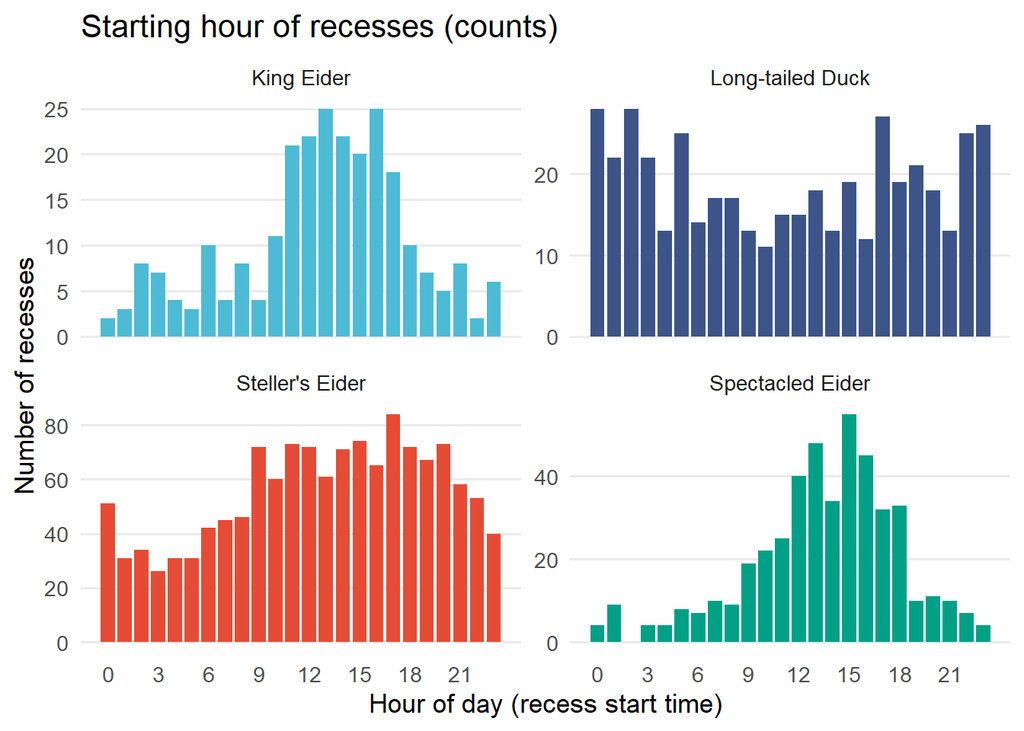

```r
core_frac <- 0.50  # dominant window contains this fraction of recesses (try 0.5–0.7)

# one row per recess w/ hour (COMMON NAMES)
recess_tod <- hen.act.filtered %>%
  filter(Behavior == "N-NotIncubating") %>%
  mutate(
    DateTimeBegin = ymd_hms(DateTimeBegin, tz = "UTC"),
    hour = lubridate::hour(DateTimeBegin),
    Species = dplyr::recode(as.character(Species), !!!species_labels),
    Species = factor(Species, levels = unname(species_labels))
  ) %>%
  filter(!is.na(hour), !is.na(Species)) %>%
  distinct(Nest_ID, Species, ID, hour)  # one per recess event

# Counts by hour
hour_counts <- recess_tod %>%
  count(Species, hour, name = "n_recesses") %>%
  # ensure all hours exist for each species (so window-finding is stable)
  tidyr::complete(Species, hour = 0:23, fill = list(n_recesses = 0L))

Fig4_count <- ggplot(hour_counts, aes(x = hour, y = n_recesses, fill = Species)) +
  geom_col(show.legend = FALSE, width = 0.85) +
  facet_wrap(~ Species, ncol = 2, scales = "free_y") +
  scale_fill_manual(values = pal_common, drop = FALSE) +
  scale_x_continuous(breaks = seq(0, 23, 3), minor_breaks = NULL) +
  labs(
    x = "Hour of day (recess start time)",
    y = "Number of recesses",
    title = "Starting hour of recesses (counts)"
  ) +
  theme_minimal(base_size = 13) +
  theme(panel.grid.minor = element_blank(),
        panel.grid.major.x = element_blank())

Fig4_count
```

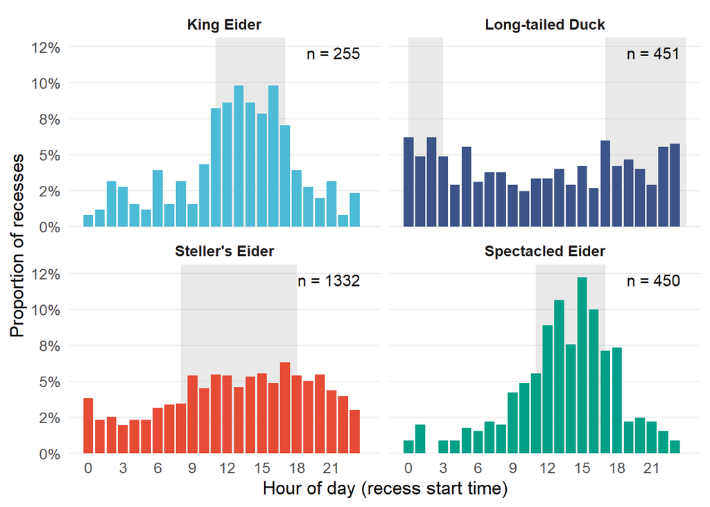

```r
# proportion by hour within species
hour_summ <- hour_counts %>%
  group_by(Species) %>%
  mutate(prop_recesses = n_recesses / sum(n_recesses, na.rm = TRUE)) %>%
  ungroup()

# --- helper: find smallest contiguous (circular) window containing core_frac of recesses
find_core_window <- function(hour, prop, frac = 0.5) {
  full <- tibble(hour = 0:23) %>%
    left_join(tibble(hour = hour, prop = prop), by = "hour") %>%
    mutate(prop = replace_na(prop, 0)) %>%
    arrange(hour)

  # duplicate for circular wrap
  h2 <- c(full$hour, full$hour + 24)
  p2 <- c(full$prop, full$prop)

  best_len <- Inf
  best_i <- best_j <- NA
  i <- 1
  s <- 0

  for (j in seq_along(p2)) {
    s <- s + p2[j]
    while (s - p2[i] >= frac) {
      s <- s - p2[i]
      i <- i + 1
    }
    # start must be within first day; window length cannot exceed 24
    if (s >= frac && h2[i] < 24 && h2[j] <= h2[i] + 24) {
      len <- h2[j] - h2[i]
      if (len < best_len) {
        best_len <- len
        best_i <- i
        best_j <- j
      }
    }
  }

  xmin <- h2[best_i]
  xmax <- h2[best_j] + 1  # +1 so last hour bin is visually included

  # if crosses midnight, return two rectangles
  if (xmax <= 24) {
    tibble(xmin = xmin, xmax = xmax)
  } else {
    bind_rows(
      tibble(xmin = xmin, xmax = 24),
      tibble(xmin = 0,    xmax = xmax - 24)
    )
  }
}

# build per-species shading rectangles
shade_df <- hour_summ %>%
  group_by(Species) %>%
  summarise(rects = list(find_core_window(hour, prop_recesses, frac = core_frac)),
            .groups = "drop") %>%
  unnest(rects) %>%
  mutate(ymin = -Inf, ymax = Inf)

# sample size recesses
n_recess_labels <- hour_counts %>%
  group_by(Species) %>%
  summarise(
    n_recess = sum(n_recesses),
    .groups = "drop"
  ) %>%
  mutate(
    label = paste0("n = ", n_recess)
  )

# Plot proportions + dominant window shading (species-specific)
Fig4 <- ggplot(hour_summ, aes(x = hour, y = prop_recesses, fill = Species)) +
  # dominant window shading
  geom_rect(
    data = shade_df,
    aes(xmin = xmin, xmax = xmax, ymin = ymin, ymax = ymax),
    inherit.aes = FALSE,
    fill = "grey30",
    alpha = 0.12
  ) +
  geom_col(show.legend = FALSE, width = 0.85) +
  facet_wrap(~ Species, ncol = 2) +
  scale_fill_manual(values = pal_common, drop = FALSE) +
  scale_x_continuous(breaks = seq(0, 23, 3), minor_breaks = NULL) +
  scale_y_continuous(
    labels = scales::percent_format(accuracy = 1),
    expand = expansion(mult = c(0, 0.05))
  ) +
  labs(
    title = NULL,
    x = "Hour of day (recess start time)",
    y = "Proportion of recesses"
  ) +
  # sample size annotation
  geom_text(
    data = n_recess_labels,
    aes(x = 23.5, y = 0.125, label = label),
    inherit.aes = FALSE,
    hjust = 1,
    vjust = 1,
    size = 4
  ) +
  theme_minimal(base_size = 13) +
  theme(
    panel.grid.minor = element_blank(),
    panel.grid.major.x = element_blank(),
    panel.grid.major.y = element_line(linewidth = 0.4),
    strip.text = element_text(face = "bold")
  )

Fig4
```

```r
ggsave(
  "Fig4.png",
  plot = Fig4,
  width = 7,
  height = 5,
  units = "in",
  dpi = 300,
  bg = "white"
)
```

**Figure 4.** Distribution of incubation recess start times across the diel cycle for four Arctic-breeding sea ducks nears Utqiaġvik, Alaska between 2011-2025. Bars show the proportion of observed recesses initiating in each hour of the day. Sample sizes (n) indicate the total number of recess per species. Shaded regions denote the smallest contiguous time interval containing 50% of recess starts.